# HW 8

Brandon Keck

2024-11-07

## Section 5.1

### 5.1-6

#### (a) Find the cdf of X

$$f(x) = 2x, \ 0 < x < 1$$

$$F(x) = \int_0^x 2t dt$$

$$=t^2]_0^x$$

$$=x^2$$

CDF F(x) is: F(x) =
$$\begin{cases}
0 & \text{if } x \le 0, \\
x^2 & \text{if } 0 < x < 1, \\
1 & \text{if } x \ge 1.
\end{cases}$$

#### (b)

We can generate a uniform random variable of U on the interval (0,1) Then we can compute that $X = \sqrt{U}$ which will give a sample from the desired distribution.

#### (c)

```r
set.seed(11101987) # Scorpio!!!

U <- runif(10)
X_sim <- sqrt(U)

X_sim
```

```
##  [1] 0.9939388 0.5424265 0.9304075 0.5688549 0.8924848 0.9234440 0.7987826
##  [8] 0.8320622 0.9788373 0.7913147
```

### 5.1-10

The lifetime (in years) of a manufactured product is Y = 5X^0.7, where X has an exponential distribution with mean 1. Find the cdf and pdf of Y.

Since X is exponential with mean 1, its PDF is:
$$f_X(x) = e^{-x}, x \ge 0$$

CDF is:
$$F_X(x)= 1 - e^{-x}, x \ge 0$$

Derive the CDF of Y
$$F_Y(y) = P(Y \le y)$$

$$= P(5X^{0.7} \le y)$$

$$= P(X^{0.7} \le \frac{y}{5})$$

$$=P(X \le (\frac{y}{5})^{\frac{1}{0.7}})$$

Express in terms of $F_X(x)$
$$F_Y(y) = F_X((\frac{y}{5})^{\frac{1}{0.7}})$$

CDF of X:
$$F_Y(y)= 1 - e^{-(\frac{1}{0.7})}, y \ge 0$$

Derive PDF of Y:
$$f_Y(y) = \frac{d}{dy}(1-e^{-(\frac{y}{5})^{\frac{1}{0.7}}})$$

$$f_Y(y)=e^{-(\frac{y}{5})^{\frac{1}{0.7}}} * \frac{d}{dy}
(-(\frac{y}{5})^{\frac{1}{0.7}})$$

$$=e^{-(\frac{y}{5})^{\frac{1}{0.7}}} * \frac{1}{5*0.7} *
(\frac{y}{5})^{\frac{1}{0.7}-1}$$

$$=\boxed{\frac{1}{3.5} * (\frac{y}{5})^{\frac{-0.3}{0.7}} *
e^{-(\frac{y}{5})^{\frac{1}{0.7}}}, y \ge 0}$$

### 5.1-17

#### (a)

The PDF of a standard normal distribution is:
$$f(x) = \frac{1}{\sqrt{2\pi}}e^{-\frac{x^2}{2}}$$

$$X^2 = Y$$

$$X = - \sqrt{Y}, \ -1 < x < 1$$

Derivative with respect to Y
$$\frac{d}{dY} - \sqrt{Y}$$

$$=\boxed{-\frac{1}{2\sqrt{Y}}}$$

$$X = \sqrt{Y}, \ 0 < x < 1$$

Derivative with respect to Y:
$$\frac{d}{dY} \sqrt{Y}$$

$$=\boxed{ \frac{1}{2\sqrt{Y}}}$$

#### (b)

$$F_Y(y) = \int_{-\sqrt{y}}^{\sqrt{y}} \frac{3}{2}x^2 \ dx$$

$$= \frac{x^3}{3}]_{-\sqrt{y}}^{\sqrt{y}}$$

$$3[\frac{x^3}{3}]_0^{\sqrt{y}}$$

$$=\sqrt{y}^3 = y^{\frac{3}{2}}$$

The CDF of Y:
$$F_Y(y) = y^{\frac{3}{2}}, \ 0 \le y \le 1$$

$$f_Y(y)= \frac{d}{dy}(y^\frac{3}{2}) = \frac{3}{2}y^{\frac{1}{2}}$$

$$f_Y(y) = \boxed{\frac{3}{2}y^{\frac{1}{2}} , \ 0 \le y \le 1}$$

## Section 5.3

### 5.3-2

#### (a)

```r
dbinom(2, size = 3, prob = 0.5)
```

```
## [1] 0.375
```

```r
dbinom(4, size = 5, prob = 0.5)
```

```
## [1] 0.15625
```

$$P(Y_1 = 2, Y_2 = 4)$$

```r
0.375 * 0.15625
```

```
## [1] 0.05859375
```

$$\boxed{0.05859375}$$

#### (b)

$$P(X_1+X_2 = 7)$$

$$X_1 + X_2 \sim b(3+5, 1/2) = b(8,1/2)$$

```r
dbinom(7, size = 8, prob = 0.5)
```

```
## [1] 0.03125
```

$$\boxed{0.03125}$$

### 5.3-3

#### (a)

$$P(0.5 < X_1 < 1) = \int_{0.5}^1 2x_1 dx_1$$

$$= x_1^2$$

$$P(0.5 < X_1 < 1) = [x_1^2]_{0.5}^1$$

$$= 1^2-(0.5)^2 = 1 - 0.25 = 0.75$$

$$P(0.5 < X_1 < 1) = 0.75$$

$$P(0.4 < X_2 < 0.8) = \int_{0.4}^{0.8} 4x_2^3 \ dx_2$$

$$= x_2^4$$

$$P(0.4 < X_2 < 0.8) = [x_2^4]_{0.4}^{0.8}$$

$$= (0.8)^4 - (0.4)^4$$

```r
(0.8)^4 - (0.4)^4
```

```
## [1] 0.384
```

```r
0.75 * 0.384
```

```
## [1] 0.288
```

$$P(0.5 < X_1 < 1 \ and \ 0.4 < X_2 < 0.8)$$

$$\boxed{0.288}$$

#### (b)

$$E(X_1^2) = \int_0^1 x_1^2 * f_1(x_1) dx_1$$

$$= \int_0^1 x_1^2 * 2x_1 dx_1$$

$$= \int_0^1 2x_1^3 dx_1$$

$$= \frac{2x_1^4}{4} = \frac{x_1^4}{2}$$

$$E(X_1) = [\frac{x_1^4}{2}]_{0}^{1} = \frac{1}{2}- 0$$

$$E(X_2^3) = \int_0^1 x_2^3 *f_2(x_2)dx_2$$

$$= \int_0^1 x_2^3 * 4x_2^3 dx_2$$

$$=\int_0^1 4x_2^6 dx_2$$

$$= \frac{4x_2^7}{7} = \frac{4}{7}x_2^7$$

$$= \frac{4}{7}-0 = \frac{4}{7}$$

```r
0.5 * 4/7
```

```
## [1] 0.2857143
```

$$\boxed{E(X_1^2X_2^3) = 0.2857143}$$

### 5.3-14

The exponential distribution
$$f(y) = \frac{1}{\lambda}e^{-\frac{1}{\lambda}y}$$

$$F(y) = P(Y \le k)$$

$$=1-P(Y > k)$$

$$\int_0^y \frac{1}{\lambda}e^{-\frac{k}{\lambda}}dk$$

$$= [\frac{1}{\lambda}
\frac{e^{-\frac{k}{\lambda}}}{-\frac{1}{\lambda}}]_0^y$$

$$=[-e^{-\frac{k}{\lambda}}]_0^y$$

$$=(1-e^{-\frac{y}{\lambda}})$$

$$=(e^{-\frac{y}{\lambda_1}})(e^{-\frac{y}{\lambda_2}})(e^{-\frac{y}{\lambda_3}})$$

$$=(e^{-\frac{1000}{1000}})(e^{-\frac{1000}{1500}})(e^{-\frac{1000}{2000}})$$

```r
# Calculate each probability term
exp(-1000 / 1000) * exp(-1000 / 1500) * exp(-1000 / 2000)
```

```
## [1] 0.1145588
```

$$\boxed{0.1145588}$$

## Section 5.4

### 5.4-2

$$X \sim b(n,p)$$

$$M_X(t) = (1-p + pe^t)^n$$

$$Since \ X_1 \sim b(n_1,p)$$

$$M_X1(t) = (1-p + pe^t)^{n1}$$

$$M_X2(t) = (1-p + pe^t)^{n2}$$

$$M_Y(t) = M_X1(t) * M_X2(t)$$

$$M_Y(t) = (1-p + pe^t)^{n1} * (1-p + pe^t)^{n2}$$

$$M_Y(t) = (1-p + pe^t)^{n1+n2}$$

The mgf $M_Y(t) = (1-p+pe^t)^{n1+n2}$ is a binomial random variable with parameters $n = n_1 + n_2$

$$\boxed{M_Y(t)= (1-p + pe^t)^{n1+n2}}$$

$$\boxed{Y \sim b(n_1+n_2)}$$

### 5.4-20

$$P(Y > 90) = \int_{90}^{\infty} f_Y(x)dx$$

$$f_Y(x) = \frac{x^{6-1}e^{-\frac{x}{10}}}{\Gamma(6)*10^6}$$

$$P(Y > 90) = \int_{90}^{\infty}
\frac{x^5e^{-\frac{x}{10}}}{\Gamma(6)*10^6} dx$$

```r
1 - pgamma(90, shape = 6, scale = 10)
```

```
## [1] 0.1156905
```

$$\boxed{0.1156905}$$

## Section 5.5

### 5.5-2

#### (a)

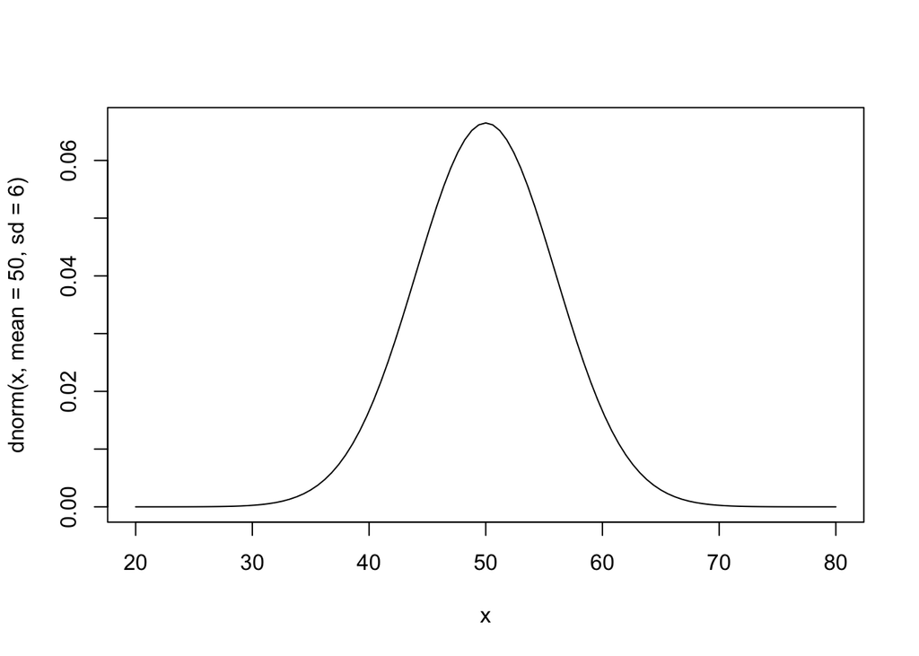

```r
curve(dnorm(x, mean = 50, sd = 6), from = 20, to = 80)
```

#### (b)

$Var(\bar{X}) = \frac{36}{9} = 4$

$SD(\bar{X}) = \sqrt{4}=2$

$Thus, \bar{X} \ follows \ a \ normal \ distribution: \bar{X} \sim N(50,4)$

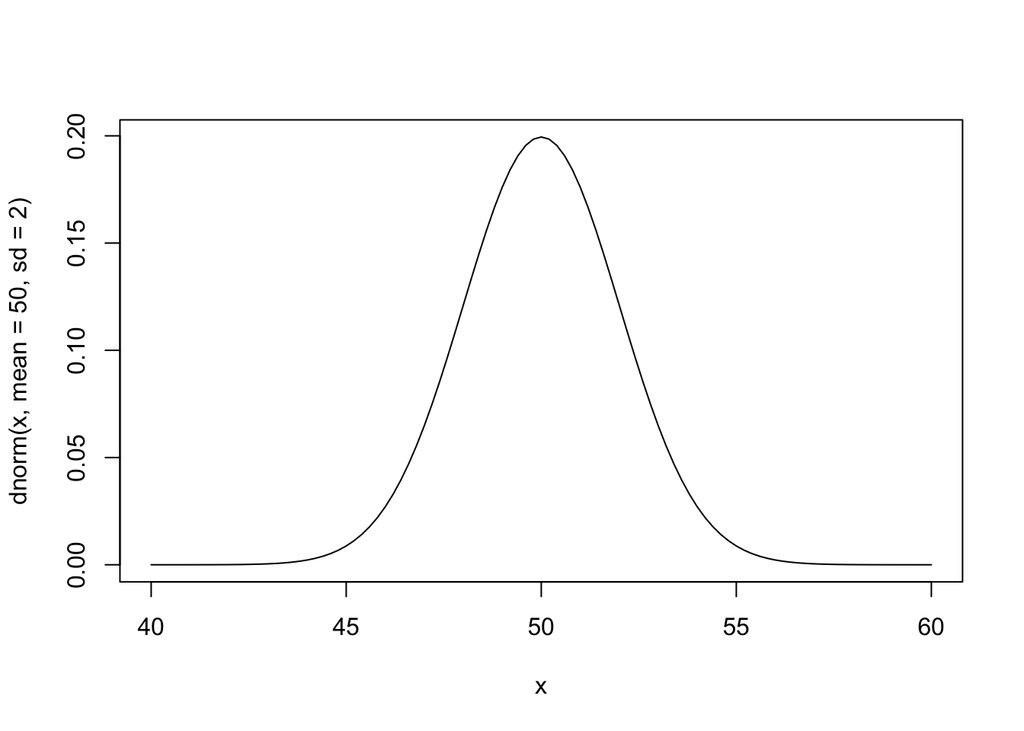

```r
curve(dnorm(x, mean = 50, sd = 2), from = 40, to = 60)
```

#### (c)

$\bar{X} \sim N(50,1)$

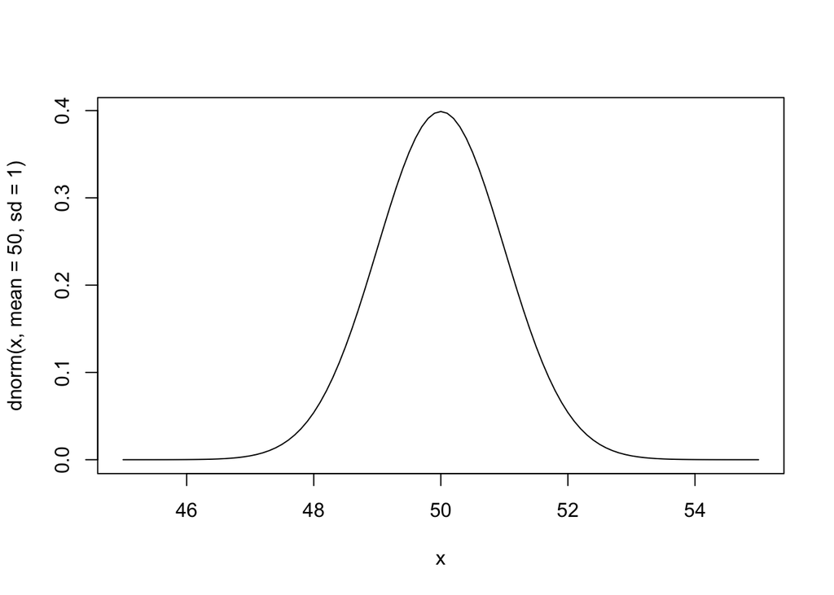

```r
curve(dnorm(x, mean = 50, sd = 1), from = 45, to = 55)
```

### 5.5-5

$\mu = 8.78 \ and \ \sigma = 0.4$

$\mu \pm 3\sigma = 8.78 \pm3 * 0.4$

$= (7.58, 9.98)$

$Variance \ of \ \bar{X} = \frac{0.16}{9}$

$\sigma = \sqrt{0.01777}$

$=0.1333$

$\mu \pm 3\sigma = 8.78 \pm 3 * 0.1333$

$=(8.38,9.2)$

[figure not shown]

```r
# Plot the PDF of X
curve(dnorm(x, mean = 8.78, sd = 0.4), from = 7.5, to = 10,
      col = adjustcolor("skyblue", alpha.f = 0.5), lwd = 1.5,
      xlab = "x", ylab = "Density",
      main = "PDFs of X and Sample Mean",
      ylim = c(0, 3))  # Set y-axis limits from 0 to 3

# Add the PDF
curve(dnorm(x, mean = 8.78, sd = 0.1333), from = 7.5, to = 10,
      col = adjustcolor("red", alpha.f = 0.5), lwd = 1.5,
      lty = 2, add = TRUE)

# Add a legend to differentiate
legend("topright", legend = c("X ~ N(8.78, 0.16)", "X̄ ~ N(8.78, 0.0167)"),
       col = c(adjustcolor("skyblue", alpha.f = 0.5), adjustcolor("red", alpha.f = 0.5)),
       lwd = 1.5, lty = c(1, 2))
```